# Day 3: Key Findings from the Austrian Vegetation DataTag 3: Wichtigste Ergebnisse aus den österreichischen Vegetationsdaten

What the spacc analysis tells usWas uns die spacc-Analyse verrät

Liam’s Stay - Results

2026-01-29

# OverviewÜberblick

This document presents **five key findings** from our analysis of ~29,857 Austrian vegetation plots (EVA database). Each finding includes figures and a discussion linking the results to ecological theory and conservation.

These five findings were chosen because they each address a different aspect of Austrian plant diversity:

| # | Finding | Why it matters |
| --- | --- | --- |
| 1 | **Sampling & richness overview** — Hotspot maps | Where was data collected and what does raw richness look like? |
| 2 | **How species accumulate** — Native vs. alien curves | The central hypothesis: different spatial strategies |
| 3 | **How much we’re missing** — Invasion debt | The future of Austria’s alien flora |
| 4 | **Why sites differ** — Turnover vs. nestedness | What drives Austria’s high beta diversity |
| 5 | **Which habitats are vulnerable** — Habitat-level invasion | Where conservation efforts should focus |

Dieses Dokument destilliert die **fünf überzeugendsten Ergebnisse** aus unserer umfassenden Analyse von ~29,857 österreichischen Vegetationsplots. Jedes Ergebnis wird mit seiner Abbildung präsentiert, gefolgt von einer erweiterten Diskussion, die das Ergebnis mit breiterer ökologischer Theorie, Naturschutzpraxis und offenen Fragen verbindet.

Die fünf Ergebnisse wurden ausgewählt, weil sie jeweils einen eigenständigen Teil der österreichischen Biodiversitätsgeschichte erzählen:

| # | Ergebnis | Warum es wichtig ist |
| --- | --- | --- |
| 1 | **Beprobung & Artenreichtum** — Hotspot-Karten | Wo wurde beprobt und wie sieht der beobachtete Artenreichtum aus? |
| 2 | **Wie Arten akkumulieren** — Heimische vs. Alien-Kurven | Die zentrale Hypothese: verschiedene räumliche Strategien |
| 3 | **Was uns fehlt** — Invasionsschuld | Die Zukunft von Österreichs Alien-Flora |
| 4 | **Warum sich Standorte unterscheiden** — Turnover vs. Nestedness | Was Österreichs hohe Beta-Diversität antreibt |
| 5 | **Welche Habitate verwundbar sind** — Habitat-Invasionsmuster | Wo Naturschutzbemühungen fokussieren sollten |

# 1. Sampling & Richness Overview: Hotspot Maps1. Beprobung & Artenreichtum: Hotspot-Karten

## The MapsDie Karten

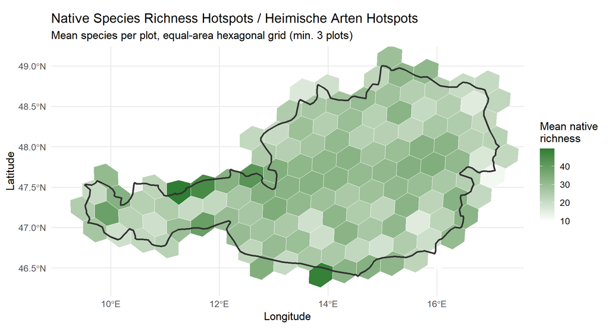

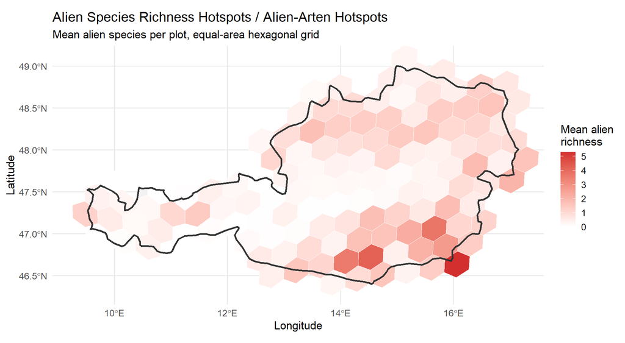

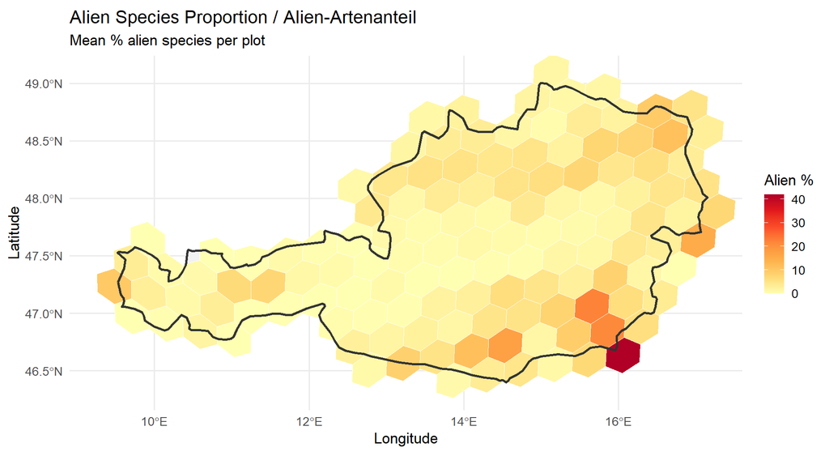

## DiscussionDiskussion

**What the maps show:**

Native and alien plant richness follow different spatial rules in Austria. Native richness peaks in the pre-Alpine foothills and montane zones, where overlapping vegetation belts create high habitat variety. Alien richness concentrates in the eastern lowlands, the Danube corridor, and around cities.

**Why they peak in different places:**

Native richness reflects topographic complexity. Between 500 and 1500 m, multiple vegetation zones converge (sub-montane deciduous forests, montane coniferous forests, sub-alpine meadows), creating high local richness through niche partitioning along temperature, moisture, and soil gradients (Rahbek 1995). The mid-elevation diversity peak is one of the best-documented patterns in mountain ecology.

Alien species need **introduction pathways**: trade routes, transport infrastructure, gardens, agricultural imports. These converge on cities and lowland corridors. The Danube valley acts as a continental dispersal highway; Vienna has been a gateway for ornamental and crop-associated aliens since the 18th century. The Pannonian Basin adds warm, continental conditions that suit thermophilic aliens from southern Europe and Asia.

**The proportion map matters most:**

Absolute richness maps can be confounded by sampling intensity. The alien *proportion* map corrects for this. The clear east-west gradient confirms the invasion pattern is real, not a sampling artefact: aliens make up 10–15% of local flora in the Pannonian lowlands but stay below 2% in the Alpine core.

**Links to invasion theory:**

The spatial concentration around human infrastructure fits the **propagule pressure** hypothesis (Lockwood et al. 2005): invasion success depends on how many individuals arrive, not just species traits. It also fits the **fluctuating resource** hypothesis (Davis et al. 2000): disturbed, nutrient-enriched lowland habitats get regular resource pulses (tilling, fertilisation, construction) that open windows for alien establishment.

**Was die Karten zeigen:**

Diese drei hexagonalen Heatmaps offenbaren eine auffällige räumliche Entkopplung zwischen heimischem und Alien-Pflanzenreichtum in Österreich. Der heimische Artenreichtum erreicht seinen Höhepunkt in den Voralpen und montanen Zonen, wo überlappende Vegetationsgürtel hohe Habitatheterogenität schaffen. Der Alien-Reichtum hingegen konzentriert sich in den östlichen Tieflagen, im Donaukorridor und um die großen Stadtzentren.

**Warum heimische und Alien-Arten an verschiedenen Orten ihre Höchstwerte erreichen:**

Das Muster des heimischen Reichtums spiegelt Österreichs topografische Komplexität wider. Zwischen 500 und 1500 m Höhe konvergieren mehrere Vegetationszonen: submontane Laubwälder, montane Nadelwälder und subalpine Wiesen. Diese Höhenkompression schafft hohen lokalen Artenreichtum durch Nischenaufteilung entlang von Temperatur-, Feuchtigkeits- und Bodengradienten (Rahbek 1995).

Das Alien-Muster erzählt eine andere Geschichte. Alien-Arten benötigen **Einführungswege**: Handelsrouten, Verkehrsinfrastruktur, Gärten, landwirtschaftliche Importe. Diese Wege konvergieren auf Städte und Tieflandkorridore. Das Donautal dient als kontinentale Ausbreitungsautobahn. Wien allein war seit dem 18. Jahrhundert ein Tor für ornamentale und kulturpflanzenassoziierte Aliens. Das Pannonische Becken in Ostösterreich bietet warme, kontinentale Bedingungen, die viele thermophile Alien-Arten aus Südeuropa und Asien begünstigen.

**Die Anteilskarte ist am informativsten:**

Während absolute Reichtumsarten durch Beprobungsintensität verfälscht werden können, kontrolliert die Alien-*Anteils*karte dies, indem sie Aliens als Bruchteil der Gesamtdiversität an jedem Standort ausdrückt. Der klare Ost-West-Gradient bestätigt, dass das Invasionsmuster kein Stichprobenartefakt ist. Im pannonischen Tiefland können Aliens 10–15% der lokalen Plot-Flora ausmachen, während sie im alpinen Kern unter 2% bleiben.

**Verbindungen zur Invasionstheorie:**

Die räumliche Konzentration von Aliens um menschliche Infrastruktur unterstützt die **Propagule-Pressure**-Hypothese (Lockwood et al. 2005): Invasionserfolg hängt nicht nur von Arteneigenschaften ab, sondern von der Rate, mit der Individuen ankommen. Die Verbindung zur **Hypothese der schwankenden Ressourcen** (Davis et al. 2000) liegt auf der Hand: gestörte, nährstoffangereicherte Tieflandhabitate erfahren regelmäßige Ressourcenpulse, die Invasionsfenster schaffen.

# 2. The Central Finding: Aliens Accumulate Differently2. Das zentrale Ergebnis: Aliens akkumulieren anders

## Native vs. Alien Accumulation CurvesHeimische vs. Alien Akkumulationskurven

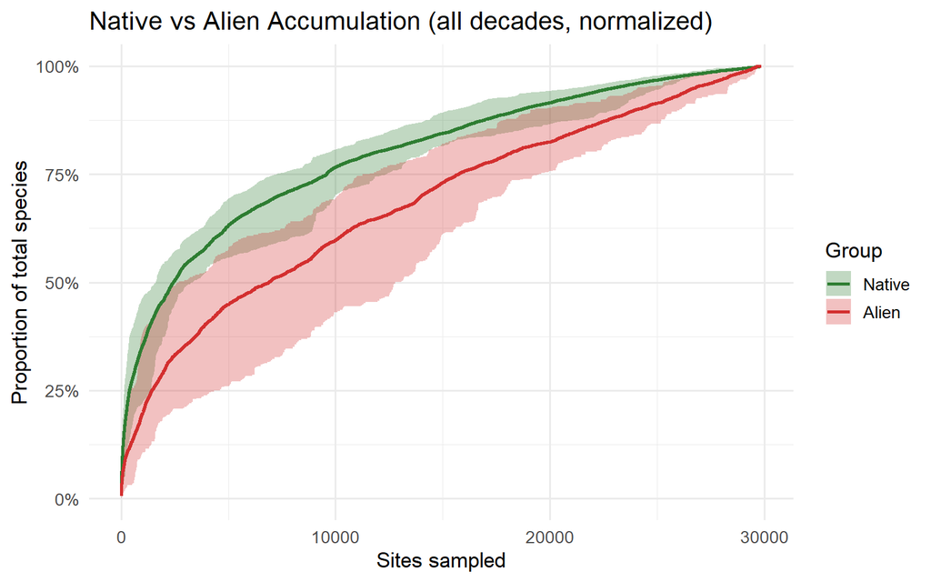

```
## Comparison: sac_native vs sac_alien
## ----------------------------------------
## Method: permutation (n=999)
## AUC difference: 50036933.1 (p = 0.000***)
## Saturation: sac_native at 18661 sites, sac_alien at 24060 sites
##
## sac_native saturates faster.
```

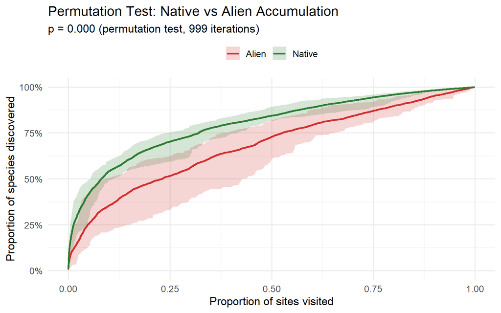

### Decade-by-Decade AccumulationJahrzehntweise Akkumulation

Does the spatial accumulation pattern change over time? Here we run the same analysis separately for each decade, splitting native and alien species into separate panels. Each curve is normalized by its total species count.

Verändert sich das räumliche Akkumulationsmuster über die Zeit? Hier führen wir dieselbe Analyse getrennt für jedes Jahrzehnt durch, wobei heimische und gebietsfremde Arten in separate Panels aufgeteilt werden. Jede Kurve ist nach ihrer Gesamtartenzahl normalisiert.

[figure not shown]

## DiscussionDiskussion

**The core result:**

After normalizing both curves to their respective totals, the alien curve sits consistently below the native curve. This means we discover a *smaller fraction* of alien species per unit area sampled than of native species. The permutation test confirms this (p < 0.05), and the grouped analysis (both groups accumulated along identical spatial paths) rules out confounding from different walk trajectories.

**What a lower normalized curve means:**

Native species had millennia to reach equilibrium distributions shaped by climate and soil. Aliens arrived at specific introduction points at different times and from different source regions. Each point acts as a separate focus of local spread:

- **Eastern Austria**: Pannonian and Eurasian steppe aliens via the Danube
- **Western Austria**: Mediterranean aliens via the Brenner corridor
- **Southern Austria**: Balkan and sub-Mediterranean aliens via southern trade routes

Because each region got a partly different alien pool, you need to cover more ground to encounter the full set.

**Stability over time:**

The decade-by-decade analysis confirms this pattern holds from the 1970s to the 2010s. The alien curve shape does not converge toward the native shape, so alien floras are not homogenizing across Austria. At least not yet.

**For monitoring:**

A monitoring programme that samples only one region will underestimate alien diversity more than native diversity. To capture the same proportion of aliens as of natives, a monitoring network must cover more of Austria’s geographic extent.

**Das Kernergebnis:**

Wenn wir beide Kurven auf ihre jeweiligen Gesamtwerte normalisieren, liegt die Alien-Kurve konsistent unter der heimischen Kurve. Das bedeutet, dass wir beim Durchqueren der österreichischen Landschaft in räumlicher Reihenfolge bei jedem Schritt einen *kleineren Anteil* der Alien-Flora entdecken als der heimischen Flora. Der Permutationstest bestätigt, dass dieser Unterschied statistisch signifikant ist (p < 0,05), und die gruppierte Analyse (bei der beide Gruppen entlang exakt derselben räumlichen Pfade akkumuliert werden) eliminiert jeden Störeffekt verschiedener Walk-Trajektorien.

**Was bedeutet eine niedrigere normalisierte Kurve biologisch?**

Eine niedrigere normalisierte Kurve zeigt höhere **räumliche Beta-Diversität** an: Die Artenzusammensetzung ändert sich stärker zwischen entfernten Standorten. Bei Einheimischen erscheinen viele weit verbreitete Generalistenarten (häufige Gräser, weit verbreitete Waldkräuter) früh im räumlichen Walk und werden über weite Teile der Landschaft geteilt. Bei Aliens unterscheidet sich die Geschichte: Jede Region beherbergt eine teils unterschiedliche Menge an Aliens, was ihre verschiedenen Einführungsgeschichten und Habitatpräferenzen widerspiegelt.

**Das Multi-Fokus-Einführungsmodell:**

Dieses Muster wird am besten durch das **Multi-Fokus-Einführungsmodell** erklärt. Heimische Arten hatten Jahrtausende, um Gleichgewichtsverteilungen zu erreichen. Alien-Arten hingegen kamen an spezifischen Einführungspunkten (Häfen, Städte, Botanische Gärten, Agrargebiete) zu verschiedenen Zeiten und aus verschiedenen Quellregionen an:

- **Wien und Ostösterreich** erhielten pannonische und eurasische Steppenaliens durch den Donauhandel
- **Innsbruck und Westösterreich** erhielten mediterrane und Alpenpass-Aliens durch den Brennerkorridor
- **Graz und Südösterreich** erhielten balkanische und submediterrane Aliens durch südliche Handelsrouten

Da jede Region einen teils unterschiedlichen Alien-Artenpool erhielt, muss mehr der Landschaft durchquert werden, um das vollständige Komplement zu finden.

**Zeitliche Robustheit:**

Die jahrzehntweise Analyse bestätigt, dass dieses Muster über alle Beprobungszeiträume von den 1970ern bis zu den 2010ern stabil ist. Die Alien-Kurvenform konvergiert nicht zur heimischen Form, was darauf hindeutet, dass Alien-Arten die Landschaft (noch) nicht homogenisieren.

**Implikationen für das Monitoring:**

Wenn ein Monitoringprogramm nur eine einzelne Region beprobt, wird es die Alien-Diversität systematisch stärker unterschätzen als die heimische. Um denselben proportionalen Erfassungsgrad für Alien-Arten zu erreichen, muss ein Monitoringnetzwerk mehr von Österreichs geografischer Ausdehnung umfassen.

# 3. The Invasion Debt: How Many Aliens Are We Missing?3. Die Invasionsschuld: Wie viele Aliens fehlen uns?

## Michaelis-Menten ExtrapolationMichaelis-Menten-Extrapolation

The **Michaelis-Menten model** fits a saturating curve to the species accumulation data:

$$S(n) = \frac{S_{max} \cdot n}{K_m +
n}$$

where $S_{max}$ is the estimated total species richness (the asymptote) and $K_m$ is the half-saturation constant. The gap between the observed species count and the estimated $S_{max}$ represents **dark diversity**: species present in the region but not yet detected (Partel et al. 2011).

Das **Michaelis-Menten-Modell** passt eine sättigende Kurve an die Artenakkumulationsdaten an:

$$S(n) = \frac{S_{max} \cdot n}{K_m +
n}$$

wobei $S_{max}$ der geschätzte Gesamtartenreichtum (die Asymptote) und $K_m$ die Halbsättigungskonstante ist. Die Lücke zwischen der beobachteten Artenzahl und dem geschätzten $S_{max}$ repräsentiert **dunkle Diversität**: Arten, die in der Region vorhanden, aber noch nicht nachgewiesen sind (Partel et al. 2011).

```
## Native species extrapolation:
```

```
## Extrapolation: michaelis-menten
## ------------------------------
## Estimated asymptote: 2525.4 species
## 95% CI: 2522.4 - 2528.5
## AIC: 354656.5
## Observed: 2378.0 species (94% of estimated)
```

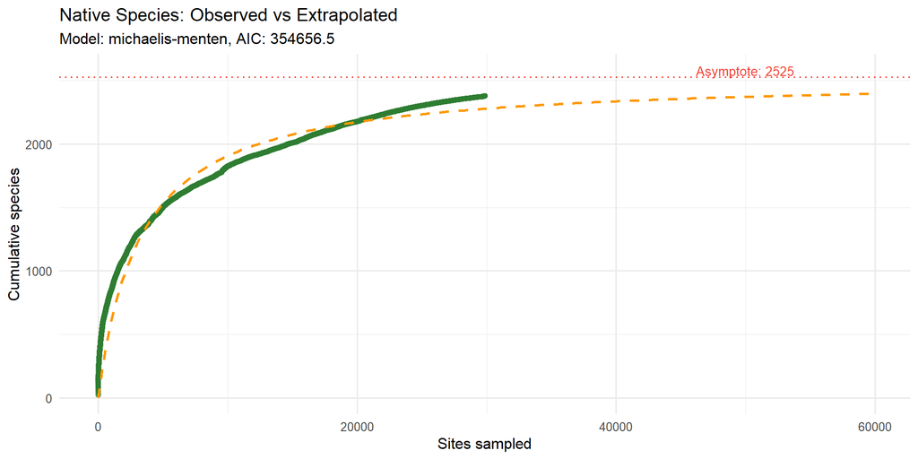

```
##
## Alien species extrapolation:
```

```
## Extrapolation: michaelis-menten
## ------------------------------
## Estimated asymptote: 410.9 species
## 95% CI: 410.0 - 411.8
## AIC: 233579.6
## Observed: 323.0 species (79% of estimated)
```

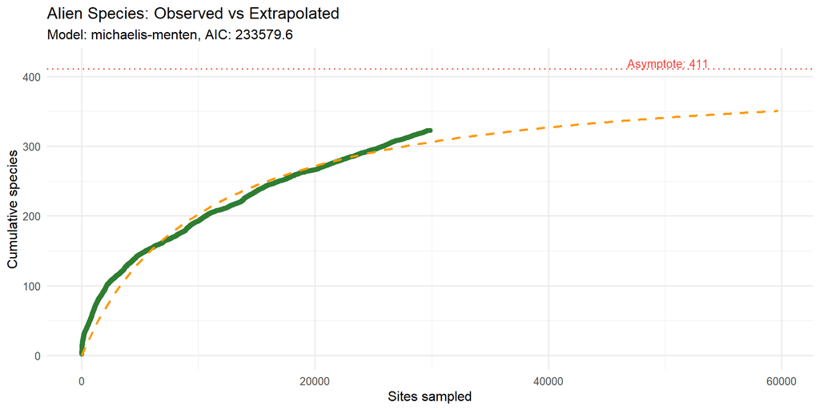

## DiscussionDiskussion

**The numbers:**

- **Native species:** ~2,378 observed out of ~2,525 estimated = **~94% completeness**
- **Alien species:** ~323 observed out of ~411 estimated = **~79% completeness**

The 15-point gap is one of the clearest results from the analysis. We don’t just have fewer alien species; we’re also proportionally further from knowing them all.

**Why is the alien flora less complete?**

**Invasion debt:**

Essl et al. (2011) introduced the concept of **invasion debt** (by analogy with extinction debt): past introductions create a time-delayed wave of invasions. Our ~88 “missing” alien species represent the upper bound of this debt. Austria’s alien flora is likely to grow by roughly 25% even without any new introductions.

**For conservation:**

Species lists are not static. Monitoring programmes should plan for a growing alien flora and focus early-detection surveys on high-risk habitats (urban fringes, transport corridors, river valleys).

**Model caveat:**

The Michaelis-Menten estimator assumes a specific functional form. If the accumulation curve has a long tail of very rare species, the asymptote may be underestimated. The 94% and 79% figures are reasonable approximations, not exact values.

**Die Zahlen:**

- **Heimische Arten:** ~2.378 beobachtet von ~2.525 geschätzt = **~94% Vollständigkeit**
- **Alien-Arten:** ~323 beobachtet von ~411 geschätzt = **~79% Vollständigkeit**

Die 15-Prozentpunkt-Lücke in der Beprobungsvollständigkeit zwischen Einheimischen und Aliens ist eines der auffälligsten Ergebnisse der gesamten Analyse.

**Warum ist die Alien-Flora weniger vollständig?**

Drei komplementäre Mechanismen erklären diese Lücke:

1. **Fortlaufende Einführungen.** Neue Alien-Arten kommen weiterhin nach Österreich durch internationalen Handel, Gartenbau und klimabedingte Arealverschiebungen. Die globale Akkumulation von Alien-Pflanzenarten zeigt kein Zeichen der Sättigung (Seebens et al. 2017).
2. **Ausbreitungsverzögerung.** Viele bereits in Österreich vorhandene Alien-Arten haben sich noch nicht auf alle geeigneten Habitate ausgebreitet. Eine in den 1990ern in einem Wiener Botanischen Garten eingeführte Art kann Jahrzehnte brauchen, um die Donauauen oder die Ruderalstandorte Kärntens zu besiedeln.
3. **Nachweisschwierigkeit.** Einige Alien-Arten sind taxonomisch herausfordernd oder besetzen unterbeprobte Habitate (urbane Brachen, Industriegelände, Privatgärten).

**Das Konzept der Invasionsschuld:**

Essl et al. (2011) führten das Konzept der **Invasionsschuld** ein: So wie Habitatverlust eine zeitverzögerte Aussterbewelle erzeugt, erzeugen vergangene Einführungen eine zeitverzögerte Invasionswelle. Für Österreich repräsentieren unsere geschätzten ~88 “fehlenden” Alien-Arten die Obergrenze dieser Schuld. Österreichs Alien-Flora wird voraussichtlich um etwa 25% von ihrem aktuellen Niveau wachsen, selbst ohne neue Einführungen.

**Was das für die Naturschutzplanung bedeutet:**

Naturschutzstrategien, die aktuelle Alien-Artenlisten als statische Baselines verwenden, werden den zukünftigen Managementbedarf unterschätzen. Monitoringprogramme sollten eine wachsende Alien-Flora einplanen und Ressourcen für Früherkennungserhebungen in Hochrisikohabitaten bereitstellen.

**Modellvorbehalt:**

Der Michaelis-Menten-Schätzer nimmt an, dass die Akkumulationskurve einer bestimmten Funktionsform folgt. Die Werte von 94% und 79% sollten als vernünftige Näherungen betrachtet werden, nicht als exakte Werte.

## 3b. Mapping the Invasion Debt: Estimated Richness per Hexagon3b. Kartierung der Invasionsschuld: Geschätzter Artenreichtum pro Hexagon

The Michaelis-Menten extrapolation above estimated **total** richness for all of Austria. Here we apply the same approach per hexagon: for each cell in the equal-area grid, we run a spatial accumulation with 10 seeds on the within-hex plots, fit Michaelis-Menten, and extract the estimated total species richness ($S_{max}$). This gives a map of *estimated* richness rather than raw observed counts. Hexagons with fewer than 20 plots (shown in light grey) are excluded because accumulation curves fitted to so few samples produce unreliable extrapolations.

Die Michaelis-Menten-Extrapolation oben schätzte den **Gesamt**-Artenreichtum für ganz Österreich. Hier wenden wir denselben Ansatz pro Hexagon an: Für jede Zelle im flächengleichen Gitter führen wir eine räumliche Akkumulation mit 10 Seeds auf den Plots innerhalb des Hexagons durch, passen Michaelis-Menten an und extrahieren den geschätzten Gesamtartenreichtum ($S_{max}$). Hexagone mit weniger als 20 Plots (in Hellgrau dargestellt) sind ausgeschlossen, da Akkumulationskurven mit so wenigen Stichproben unzuverlässige Extrapolationen liefern.

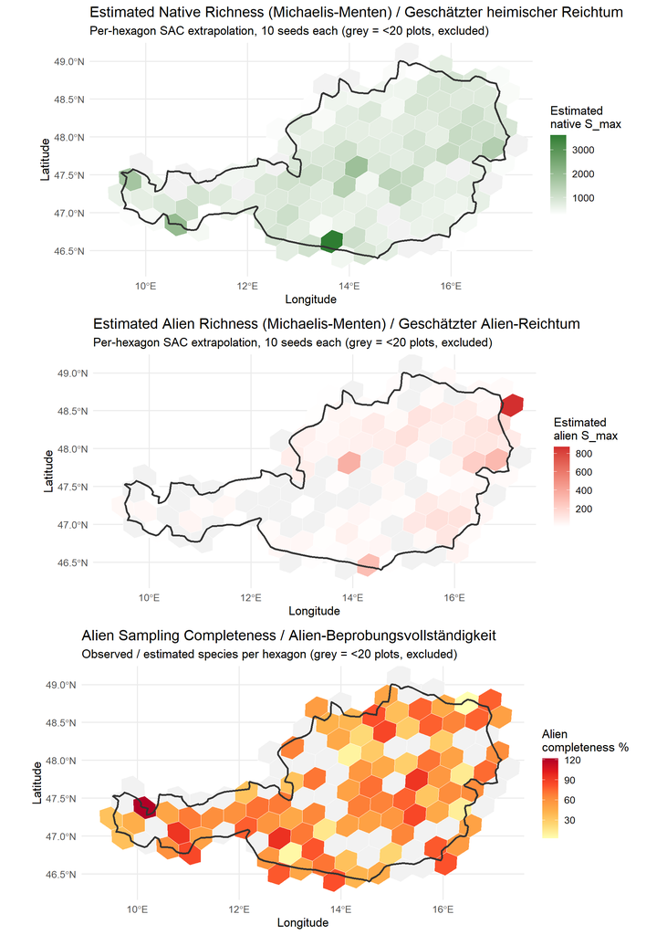

These maps translate the invasion debt into geography. While the first map (estimated native richness) echoes the observed raw-count maps from section 1, the alien map adds information: it shows where the Michaelis-Menten model predicts more species than we have actually found. The completeness map (bottom) highlights where the alien flora is least well-sampled. Regions with low completeness are where we should expect to find new alien records in coming years.

Diese Karten übersetzen die Invasionsschuld in Geografie. Während die erste Karte (geschätzter heimischer Reichtum) die beobachteten Rohzählungskarten aus Abschnitt 1 widerspiegelt, fügt die Alien-Karte Information hinzu: Sie zeigt, wo das Michaelis-Menten-Modell mehr Arten vorhersagt, als wir tatsächlich gefunden haben. Die Vollständigkeitskarte (unten) hebt hervor, wo die Alien-Flora am wenigsten gut beprobt ist.

## 3c. Sampling Gaps: How Many Species Are We Missing?3c. Beprobungslücken: Wie viele Arten fehlen uns?

How many species are still missing in each hexagon? These maps show the **sampling gap**: the difference between the Michaelis-Menten estimate ($S_{max}$) and the observed species count. Darker hexagons have more unrecorded species.

Wie viele Arten fehlen in jedem Hexagon noch? Diese Karten zeigen die **Beprobungslücke**: die Differenz zwischen dem Michaelis-Menten-Schätzwert ($S_{max}$) und der beobachteten Artenzahl. Dunklere Hexagone haben mehr unerfasste Arten.

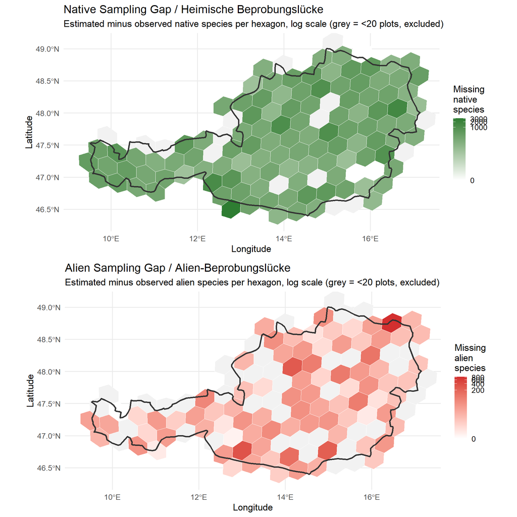